# ImpulseDE2 Tutorial

David S. Fischer

2017-01-24

# 1 Introduction

ImpulseDE2 is a parallelizable differential expression algorithm for longitudinal count data sets which arise in sequencing experiments such as RNA-seq, ChIP-seq, ATAC-seq and DNaseI-seq. ImpulseDE2 can correct for batch effects (from multiple confounding variables) and library depth. We distinguish case-only and case-control differential expression analysis: Case-only differential expression analysis tests, whether the expression level of a gene changes over time. Case-control differential expression analysis tests, whether the expression trajectory of a gene over time differes between samples from a case and samples from a control condition. Here, we demonstrate the usage of ImpulseDE2 in different scenarios based on simulated data.

To run ImpulseDE2 on bulk omics count data, a user should consider the minimal parameter set for the wrapper function runImpulseDE2:

- matCountData
- dfAnnotation
- boolCaseCtrl
- vecConfounders

Additionally, one can provide:

- scaNProc to set the number of processes for parallelisation.
- scaQThres to set the cut off for your DE gene list.
- vecDispersionsExternal to supply external dispersion parameters which may be necessary depending on your confounding factors (runImpulseDE2 will tell you if it is necessary).
- vecSizeFactorsExternal to supply external size factors.
- boolVerbose to control stdout output.

# 2 Case-only differential expression analysis

The integer count matrix (matCountData) and the sample meta data table (dfAnnotation) are created by the simulation function and handed directly to the ImpulseDE2 wrapper (runImpulseDE2). This analysis is a case-only differential expression analysis (boolCaseCtrl is FALSE). We assume that there is no batch structure (vecBatchesA) and do accordingly not give any confounding variables (vecConfounders) to ImpulseDE2. One could parallelize ImpulseDE2 by allowing more than one thread for runImpulseDE2 (scaNProc).

The differential expression results can be accessed as a data frame in the output object via objectImpulseDE2$dfImpulseDE2Results. The output object is an instance of the class ImpulseDE2Object which carries additional internal data which can be accessed via accessor functions starting with “get_”.

```r
library(ImpulseDE2)
lsSimulatedData <- simulateDataSetImpulseDE2(
  vecTimePointsA   = rep(seq(1,8),3),
  vecTimePointsB   = NULL,
  vecBatchesA      = NULL,
  vecBatchesB      = NULL,
  scaNConst        = 30,
  scaNImp          = 10,
  scaNLin          = 10,
  scaNSig          = 10,
  scaMuBatchEffect = NULL,
  scaSDBatchEffect = NULL,
  dirOutSimulation = NULL)
```

```r
lsSimulatedData$dfAnnotation
```

```
##            Sample Condition Time  Batch
## A_1_Rep1 A_1_Rep1      case    1 B_NULL
## A_2_Rep1 A_2_Rep1      case    2 B_NULL
## A_3_Rep1 A_3_Rep1      case    3 B_NULL
## A_4_Rep1 A_4_Rep1      case    4 B_NULL
## A_5_Rep1 A_5_Rep1      case    5 B_NULL
## A_6_Rep1 A_6_Rep1      case    6 B_NULL
## A_7_Rep1 A_7_Rep1      case    7 B_NULL
## A_8_Rep1 A_8_Rep1      case    8 B_NULL
## A_1_Rep2 A_1_Rep2      case    1 B_NULL
## A_2_Rep2 A_2_Rep2      case    2 B_NULL
## A_3_Rep2 A_3_Rep2      case    3 B_NULL
## A_4_Rep2 A_4_Rep2      case    4 B_NULL
## A_5_Rep2 A_5_Rep2      case    5 B_NULL
## A_6_Rep2 A_6_Rep2      case    6 B_NULL
## A_7_Rep2 A_7_Rep2      case    7 B_NULL
## A_8_Rep2 A_8_Rep2      case    8 B_NULL
## A_1_Rep3 A_1_Rep3      case    1 B_NULL
## A_2_Rep3 A_2_Rep3      case    2 B_NULL
## A_3_Rep3 A_3_Rep3      case    3 B_NULL
## A_4_Rep3 A_4_Rep3      case    4 B_NULL
## A_5_Rep3 A_5_Rep3      case    5 B_NULL
## A_6_Rep3 A_6_Rep3      case    6 B_NULL
## A_7_Rep3 A_7_Rep3      case    7 B_NULL
## A_8_Rep3 A_8_Rep3      case    8 B_NULL
```

```r
objectImpulseDE2 <- runImpulseDE2(
  matCountData    = lsSimulatedData$matObservedCounts,
  dfAnnotation    = lsSimulatedData$dfAnnotation,
  boolCaseCtrl    = FALSE,
  vecConfounders  = NULL,
  scaNProc        = 1 )
```

```r
head(objectImpulseDE2$dfImpulseDE2Results)
```

```
##        Gene         p      padj loglik_full loglik_red df_full df_red
## gene1 gene1 0.9450309 0.9450309  -140.49744 -141.09664       7      2
## gene2 gene2 0.3892921 0.7299226  -163.67896 -166.29039       7      2
## gene3 gene3 0.6522531 0.8199012  -166.65783 -168.31302       7      2
## gene4 gene4 0.7407184 0.8546751  -160.24289 -161.61053       7      2
## gene5 gene5 0.5437470 0.7957274  -130.89248 -132.91222       7      2
## gene6 gene6 0.6366019 0.8199012   -50.69109  -52.39755       7      2
##             mean converge_impulse converge_const allZero
## gene1 341.367966                0              0   FALSE
## gene2 785.117982                0              0   FALSE
## gene3 813.808617                0              0   FALSE
## gene4 646.219621                0              0   FALSE
## gene5 202.722300                0              0   FALSE
## gene6   4.496839                0              0   FALSE
```

# 3 Batch effects

Here, we present a case-only differential expression scenario with batch effects. Refer to “Case-only differential expression analysis” for details. In addition, we simulate batch effects (vecBatchesA): Here we assume that three batches of replicates was sampled with each batch sampled at each time point. Such a batch structure could arise if patient-derived cell cultures are sampled over a time course, each batch would be one patient. Another scenario is that all samples originate from the same cell culture but were handled separately.

This confounding variable imposing the batch structure on the expression observations is called “Batch” in the meta data table (dfAnnotation). By handing this confounding variable to ImpulseDE2 via the vector vecConfounders, we turn on ImpulseDE2 batch effect correction for this confounding variable.

```r
library(ImpulseDE2)
lsSimulatedData <- simulateDataSetImpulseDE2(
  vecTimePointsA   = rep(seq(1,8),3),
  vecTimePointsB   = NULL,
  vecBatchesA      = c(rep("B1",8), rep("B2",8), rep("B3",8)),
  vecBatchesB      = NULL,
  scaNConst        = 30,
  scaNImp          = 10,
  scaNLin          = 10,
  scaNSig          = 10,
  scaMuBatchEffect = 1,
  scaSDBatchEffect = 0.2,
  dirOutSimulation = NULL)
```

```r
lsSimulatedData$dfAnnotation
```

```
##            Sample Condition Time Batch
## A_1_Rep1 A_1_Rep1      case    1    B1
## A_2_Rep1 A_2_Rep1      case    2    B1
## A_3_Rep1 A_3_Rep1      case    3    B1
## A_4_Rep1 A_4_Rep1      case    4    B1
## A_5_Rep1 A_5_Rep1      case    5    B1
## A_6_Rep1 A_6_Rep1      case    6    B1
## A_7_Rep1 A_7_Rep1      case    7    B1
## A_8_Rep1 A_8_Rep1      case    8    B1
## A_1_Rep2 A_1_Rep2      case    1    B2
## A_2_Rep2 A_2_Rep2      case    2    B2
## A_3_Rep2 A_3_Rep2      case    3    B2
## A_4_Rep2 A_4_Rep2      case    4    B2
## A_5_Rep2 A_5_Rep2      case    5    B2
## A_6_Rep2 A_6_Rep2      case    6    B2
## A_7_Rep2 A_7_Rep2      case    7    B2
## A_8_Rep2 A_8_Rep2      case    8    B2
## A_1_Rep3 A_1_Rep3      case    1    B3
## A_2_Rep3 A_2_Rep3      case    2    B3
## A_3_Rep3 A_3_Rep3      case    3    B3
## A_4_Rep3 A_4_Rep3      case    4    B3
## A_5_Rep3 A_5_Rep3      case    5    B3
## A_6_Rep3 A_6_Rep3      case    6    B3
## A_7_Rep3 A_7_Rep3      case    7    B3
## A_8_Rep3 A_8_Rep3      case    8    B3
```

```r
objectImpulseDE2 <- runImpulseDE2(
  matCountData    = lsSimulatedData$matObservedCounts,
  dfAnnotation    = lsSimulatedData$dfAnnotation,
  boolCaseCtrl    = FALSE,
  vecConfounders  = c("Batch"),
  scaNProc        = 1 )
```

```r
head(objectImpulseDE2$dfImpulseDE2Results)
```

```
##        Gene         p      padj loglik_full loglik_red df_full df_red
## gene1 gene1 0.4289595 0.6773045   -156.7976  -159.2446       9      4
## gene2 gene2 0.3877292 0.6531968   -154.0320  -156.6501       9      4
## gene3 gene3 0.9691686 0.9855952   -121.4234  -121.8806       9      4
## gene4 gene4 0.3919181 0.6531968   -142.3781  -144.9783       9      4
## gene5 gene5 0.4881067 0.6998523   -158.5194  -160.7388       9      4
## gene6 gene6 0.1385559 0.3606729   -135.0996  -139.2687       9      4
##           mean converge_impulse converge_const allZero
## gene1 572.7836                0              0   FALSE
## gene2 459.7808                0              0   FALSE
## gene3 116.8797                0              0   FALSE
## gene4 293.1229                0              0   FALSE
## gene5 677.3936                0              0   FALSE
## gene6 267.8544                0              0   FALSE
```

# 4 Plot gene-wise trajectories

Here, we present the visualization of gene-wise expression trajectory fits. Refer to “Batch effects” for details on the data and the inferred model.

The user can decide whether to plot the expression trajectories with the lowest q-values (set the number of trajectories to plot, scaNTopIDs) or to plot specific trajectories (supply a vector of gene identifiers, row names of matCounts via vecGeneIDs). The central input to plotGenes is an ImpulseDE2 output object (objectImpulseDE2) which carries fits and data. The user can specifiy whether case and control fits are to be plotted (boolCaseCtrl).

The plots can be annotated with p- or q-values from an alternative differential expression algorithm: Supply a vector of the alternative p-values (vecRefPval) named with the rownames (gene identifiers) of matCounts and a name of the alternative method to the plotGenes (strNameRefMethod). The values will are added into the plot title.

The plots are printed to a .pdf if an output directory (dirOut) and file name (strFileName) is given. Alternatively, the user can also directly access the plot objects made with ggplot2 via the output list of ggplot2 plots.

Note that the observations in the plot are size factor normalised to guide the evaluation of the model. The model is not fit on normalised data but the model is normalised itself based on the factors used for data normalisation here.

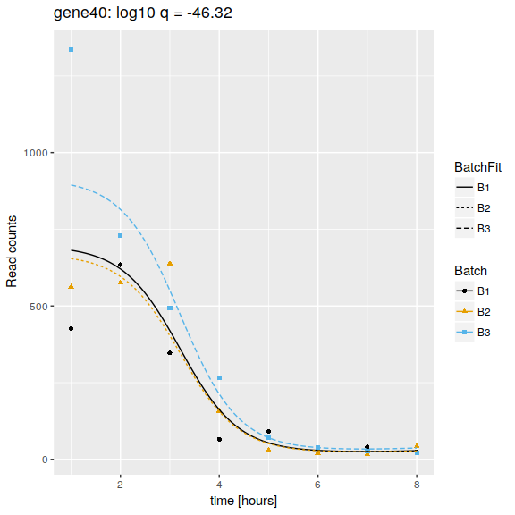

```r
# Continue script of "Batch effects"
library(ggplot2)
lsgplotsGenes <- plotGenes(
  vecGeneIDs       = NULL,
  scaNTopIDs       = 10,
  objectImpulseDE2 = objectImpulseDE2,
  boolCaseCtrl     = FALSE,
  dirOut           = NULL,
  strFileName      = NULL,
  vecRefPval       = NULL,
  strNameRefMethod = NULL)
print(lsgplotsGenes[[1]])
```

# 5 Case-control differential expression analysis

Here, we present a case-control differential expression scenario with batch effects. Refer to “Batch effects” for details. Building on the scenarios presented previously, we now have samples from two conditions (vecTimePointsA (case) and vecTimePointsB (control)) with 8 time points and three replicates each, one replicate per batch. Here, the batches do not overlap the conditions.

```r
lsSimulatedData <- simulateDataSetImpulseDE2(
  vecTimePointsA   = rep(seq(1,8),3),
  vecTimePointsB   = rep(seq(1,8),3),
  vecBatchesA      = c(rep("B1",8), rep("B2",8), rep("B3",8)),
  vecBatchesB      = c(rep("C1",8), rep("C2",8), rep("C3",8)),
  scaNConst        = 30,
  scaNImp          = 10,
  scaNLin          = 10,
  scaNSig          = 10,
  scaMuBatchEffect = 1,
  scaSDBatchEffect = 0.1,
  dirOutSimulation = NULL)
```

```r
lsSimulatedData$dfAnnotation
```

```
##            Sample Condition Time Batch
## A_1_Rep1 A_1_Rep1      case    1    B1
## A_2_Rep1 A_2_Rep1      case    2    B1
## A_3_Rep1 A_3_Rep1      case    3    B1
## A_4_Rep1 A_4_Rep1      case    4    B1
## A_5_Rep1 A_5_Rep1      case    5    B1
## A_6_Rep1 A_6_Rep1      case    6    B1
## A_7_Rep1 A_7_Rep1      case    7    B1
## A_8_Rep1 A_8_Rep1      case    8    B1
## A_1_Rep2 A_1_Rep2      case    1    B2
## A_2_Rep2 A_2_Rep2      case    2    B2
## A_3_Rep2 A_3_Rep2      case    3    B2
## A_4_Rep2 A_4_Rep2      case    4    B2
## A_5_Rep2 A_5_Rep2      case    5    B2
## A_6_Rep2 A_6_Rep2      case    6    B2
## A_7_Rep2 A_7_Rep2      case    7    B2
## A_8_Rep2 A_8_Rep2      case    8    B2
## A_1_Rep3 A_1_Rep3      case    1    B3
## A_2_Rep3 A_2_Rep3      case    2    B3
## A_3_Rep3 A_3_Rep3      case    3    B3
## A_4_Rep3 A_4_Rep3      case    4    B3
## A_5_Rep3 A_5_Rep3      case    5    B3
## A_6_Rep3 A_6_Rep3      case    6    B3
## A_7_Rep3 A_7_Rep3      case    7    B3
## A_8_Rep3 A_8_Rep3      case    8    B3
## B_1_Rep1 B_1_Rep1   control    1    C1
## B_2_Rep1 B_2_Rep1   control    2    C1
## B_3_Rep1 B_3_Rep1   control    3    C1
## B_4_Rep1 B_4_Rep1   control    4    C1
## B_5_Rep1 B_5_Rep1   control    5    C1
## B_6_Rep1 B_6_Rep1   control    6    C1
## B_7_Rep1 B_7_Rep1   control    7    C1
## B_8_Rep1 B_8_Rep1   control    8    C1
## B_1_Rep2 B_1_Rep2   control    1    C2
## B_2_Rep2 B_2_Rep2   control    2    C2
## B_3_Rep2 B_3_Rep2   control    3    C2
## B_4_Rep2 B_4_Rep2   control    4    C2
## B_5_Rep2 B_5_Rep2   control    5    C2
## B_6_Rep2 B_6_Rep2   control    6    C2
## B_7_Rep2 B_7_Rep2   control    7    C2
## B_8_Rep2 B_8_Rep2   control    8    C2
## B_1_Rep3 B_1_Rep3   control    1    C3
## B_2_Rep3 B_2_Rep3   control    2    C3
## B_3_Rep3 B_3_Rep3   control    3    C3
## B_4_Rep3 B_4_Rep3   control    4    C3
## B_5_Rep3 B_5_Rep3   control    5    C3
## B_6_Rep3 B_6_Rep3   control    6    C3
## B_7_Rep3 B_7_Rep3   control    7    C3
## B_8_Rep3 B_8_Rep3   control    8    C3
```

```r
objectImpulseDE2 <- runImpulseDE2(
  matCountData    = lsSimulatedData$matObservedCounts,
  dfAnnotation    = lsSimulatedData$dfAnnotation,
  boolCaseCtrl    = TRUE,
  vecConfounders  = c("Batch"),
  scaNProc        = 1 )
```

```r
head(objectImpulseDE2$dfImpulseDE2Results)
```

```
##        Gene          p       padj loglik_full loglik_red df_full df_red
## gene1 gene1 0.10049998 0.43071420   -301.8210  -306.4325      17     12
## gene2 gene2 0.09058622 0.43071420   -323.7719  -328.5237      17     12
## gene3 gene3 0.71468584 0.97844877   -226.2141  -227.6664      17     12
## gene4 gene4 0.56113082 0.91166808   -317.4102  -319.3697      17     12
## gene5 gene5 0.82269791 1.00000000   -309.5027  -310.5962      17     12
## gene6 gene6 0.01166924 0.08751928   -318.7218  -326.0775      17     12
##            mean converge_combined converge_case converge_control allZero
## gene1 446.21812                 0             0                0   FALSE
## gene2 744.56545                 0             0                0   FALSE
## gene3  91.76164                 0             0                0   FALSE
## gene4 545.52847                 0             0                0   FALSE
## gene5 545.26195                 0             0                0   FALSE
## gene6 737.03926                 0             0                0   FALSE
```

# 6 Transiently regulated genes

Here, we present the identification of transiently regulated genes. Refer to “Batch effects” for details. Setting boolIdentifyTransients = TRUE causes the wrapper runImpulseDE2 to also fit sigmoid models and to perform the additional model selection yielding transiently and permanently regulated genes. The results of this analysis are are also in the results table objectImpulseDE2$dfImpulseDE2Results.

```r
library(ImpulseDE2)
lsSimulatedData <- simulateDataSetImpulseDE2(
  vecTimePointsA   = rep(seq(1,8),3),
  vecTimePointsB   = NULL,
  vecBatchesA      = c(rep("B1",8), rep("B2",8), rep("B3",8)),
  vecBatchesB      = NULL,
  scaNConst        = 100,
  scaNImp          = 700,
  scaNLin          = 100,
  scaNSig          = 100,
  scaMuBatchEffect = 1,
  scaSDBatchEffect = 0.2,
  dirOutSimulation = NULL)
objectImpulseDE2 <- runImpulseDE2(
  matCountData           = lsSimulatedData$matObservedCounts,
  dfAnnotation           = lsSimulatedData$dfAnnotation,
  boolCaseCtrl           = FALSE,
  vecConfounders         = c("Batch"),
  boolIdentifyTransients = TRUE,
  scaNProc               = 1 )
```

```r
head(objectImpulseDE2$dfImpulseDE2Results)
```

```
##        Gene         p      padj loglik_full loglik_red df_full df_red
## gene1 gene1 0.6118360 0.6992412   -142.8808  -144.6691       9      4
## gene2 gene2 0.6386992 0.7225104   -154.8561  -156.5557       9      4
## gene3 gene3 0.6578924 0.7374109   -164.7760  -166.4128       9      4
## gene4 gene4 0.7107094 0.7809993   -132.7714  -134.2367       9      4
## gene5 gene5 0.9401667 0.9535159   -149.1429  -149.7670       9      4
## gene6 gene6 0.4312398 0.5394005   -140.4001  -142.8379       9      4
##           mean converge_impulse converge_const converge_sigmoid
## gene1 254.9622                0              0                0
## gene2 540.2218                0              0                0
## gene3 794.7834                0              0                0
## gene4 202.4222                0              0                0
## gene5 414.1203                0              0                0
## gene6 404.5440                0              0                0
##       impulseTOsigmoid_p impulseTOsigmoid_padj sigmoidTOconst_p
## gene1          0.3477754             0.7495188        0.6905657
## gene2          0.2881072             0.6909045        0.8229401
## gene3          0.8794952             0.9595121        0.3890509
## gene4          0.7620597             0.9116087        0.4960633
## gene5          0.8217538             0.9305174        0.8361249
## gene6          0.7597014             0.9116087        0.2283435
##       sigmoidTOconst_padj isTransient isMonotonous allZero
## gene1           0.7786494       FALSE        FALSE   FALSE
## gene2           0.8819656       FALSE        FALSE   FALSE
## gene3           0.5085633       FALSE        FALSE   FALSE
## gene4           0.6109154       FALSE        FALSE   FALSE
## gene5           0.8896959       FALSE        FALSE   FALSE
## gene6           0.3295686       FALSE        FALSE   FALSE
```

# 7 Plot global heatmap of expression trajectories

Here, we present the visualisation of global expression patterns via a heatmap. We base this analysis on a classification of differntially expressed genes by the transient regulation scheme. Refer to “Transiently regulated genes” for details.

The function plotHeatmap takes an output object of the class ImpulseDE2Object. If sigmoid model were fit and a the results table includes analysis results of transient regulation (i.e. the output of runImpulseDE2 with boolIdentifyTransients = TRUE), the heatmap can be grouped by the results of the transient regulation analysis (boolIdentifyTransients = TRUE). If transient regulation analysis was not performed, a simple heatmap of the global expression profiles is created. The condition to which sigmoids were fit and based on which the transient analysis was performed has to be indicated (strCondition), this is usually the case condition. Finally, a false-discovery rate corrected p-value threshold for the model selection of the transient regulation analysis has to be set via scaQThres.

The output of plotHeatmap includes two objects of the class ComplexHeatmap which can be plotted with draw().

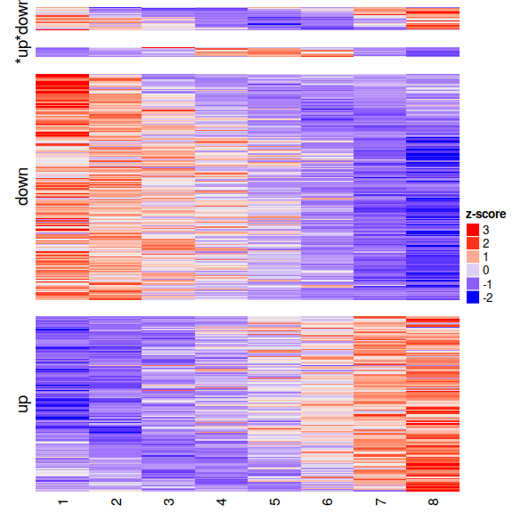

```r
# Continuing script of "Transiently regulated genes"
library(ComplexHeatmap)
lsHeatmaps <- plotHeatmap(
  objectImpulseDE2       = objectImpulseDE2,
  strCondition           = "case",
  boolIdentifyTransients = TRUE,
  scaQThres              = 0.01)
draw(lsHeatmaps$complexHeatmapRaw) # Heatmap based on normalised counts
```